# Exploring the phylogenetic composition of microbiomes

Some of this code as been adapted from the [ECOSCOPE GitHub account](https://github.com/EDUCE-UBC)

## Table of contents

#### 1. Prior to the workshop

#### 2. Getting started with R

#### 3. Building a microbial phylogenetic tree

#### 4. Diversity analysis in R

#### 5. PhyloFactor

## 1. Prior to the workshop

### Setup

Please come to the workshop with your laptop set up with the required software and data files as described in our [setup instructions](https://github.com/FloMazel/Microbiome_Phylo_Diversity_Workshop/blob/master/SetUp.md).

### Background

Please read [Hallam SJ *et al*. 2017. Sci Data 4: 170158](https://www.ncbi.nlm.nih.gov/pmc/articles/PMC5663219/) “Monitoring microbial responses to ocean deoxygenation in a model oxygen minimum zone” to learn more about the data used in this workshop. You can also check out this [short video](https://drive.google.com/file/d/1s6V263-Vj2KQ6rExOBaYn-UDOERyQVGZ/view?usp=sharing) showing how the sampling was done!

### Data description

The data in this workshop were collected as part of an on-going oceanographic time series program in Saanich Inlet, a seasonally anoxic fjord on the East coast of Vancouver Island, British Columbia

## 2. Getting started with R

### Installing and loading packages

At the beginning of every R script, you should have a dedicated space for loading R packages. R packages allow any R user to code reproducible functions and share them with the R community. Packages exist for anything ranging from microbial ecology to complex graphics to multivariate modeling and beyond.

In this workshop, we will use several packages:

- tidyverse
- ape
- sequinR
- vegan
- phyloseq
- betapart
- abind
- Matrix
- phytools
- ggplot2
- cowplot
- phylofactor

Please MAKE SURE they are installed in your computer. If not, refer to [setup instructions](https://github.com/FloMazel/Microbiome_Phylo_Diversity_Workshop/blob/master/SetUp.md)

### Load the packages

```r
library(seqinr)
library(ape)
library(vegan)
library(tidyverse)
library(phyloseq)
library(betapart)
library(abind)
library(tidyr)
library(Matrix)
```

```r
library(ggplot2)
library(cowplot)
library(phylofactor)
```

### Setting your working directory

Copy the workshop folder “Working directory” from GitHub on your computer

Then tell R that this is going to be the folder where we are going to work

In Flo case:

```r
setwd("/Users/fmazel/Documents/GitHub/Microbiome_Phylo_Diversity_Workshop")
```

### Importing custom R functions

We have written some custom R functions for use in this workshop. It is good practice to define these functions in a separate file and then to import them into your scripts, so that you don’t duplicate the code. (Duplication, you may recall, can end up in mutation! ;) )

```r
source("./R functions/BDTT_functions.R")
```

## 3. Building a microbial phylogenetic tree

### 3.1. Alignment

We are not going to cover this stage here, as it will be carried out in other workshops. Many software offer to align sequences, some of them are wrapped within [Mothur](https://www.mothur.org) or [Qiime2](https://qiime2.org) For example you can look at this [tutorial](https://github.com/FloMazel/Microbiome_Phylo_Diversity_Workshop/blob/master/data/mothur_pipeline.html) producing the data we are going to use here.

### 3.2. Tree Building

Typical read length in microbiome studies are relatively short and have thus contains limited information to reconstruct phylogeentic trees, especially to reconstruct deep branches. To avoid biased phylogenies, we thus constrains deep branches to follow taxonomic classification as it is admitted that large taxonomic clades are monophyletic (informations based on longer sequences). The choice of the constrains is not easy. Here we will constain tree reconstruction by Domain (Bacteria/Archea) and phylums.

We will use FastTree to reconstruct the phylogeneic hypotheses. While fastTree is not the best software to reconstruct phylogenies (because it makes a lot of approximations), it has the huge avantage to be fast, which is often critical in microbial species, as there are a very high number of “species”.

#### Topological constrains

Load the taxonomic file

```r
taxonomy.raw = read.table("data/Saanich_cruise72_mothur_OTU_taxonomy.taxonomy", sep="\t", header=TRUE, row.names=1)
taxonomy= taxonomy.raw %>%
  select(-Size) %>%
  separate(Taxonomy, c("Domain", "Phylum", "Class", "Order", "Family", "Genus", "Species"), sep=";")
```

Change the name of the fasta alignment file

```r
alignment=read.fasta("data/mothur_intermediate_files/Saanich.final.opti_mcc.unique_list.0.03.rep.fasta")
names(alignment)=rownames(taxonomy)
```

Remove OTUS not assigned to a domain

```r
taxonomy=subset(taxonomy,!Domain=="unknown")
```

Domain constrains

```r
taxonomy[["Bacteria"]][taxonomy$Domain=="Bacteria"]=1
taxonomy[["Bacteria"]][taxonomy$Domain=="Archaea"]=0
```

Phylum constrains

```r
Phylum=unique(taxonomy$Phylum)
Phylum=subset(Phylum,!Phylum%in%c("unknown_unclassified","Bacteria_unclassified", "Archaea_unclassified")) #remove this factor

for (i in Phylum)
  {
  taxonomy[[as.character(i)]][taxonomy$Phylum==i]=1
  taxonomy[[as.character(i)]][!taxonomy$Phylum==i]=0
  }

Constrains=taxonomy[,c("Bacteria",as.character(Phylum))] #keep only the constrains
head(Constrains)
```

```
##         Bacteria Proteobacteria Bacteroidetes Thaumarchaeota
## Otu0001        1              1             0              0
## Otu0002        1              1             0              0
## Otu0003        1              1             0              0
## Otu0004        1              1             0              0
## Otu0005        1              1             0              0
## Otu0006        1              1             0              0
##         Actinobacteria Marinimicrobia_(SAR406_clade) Planctomycetes
## Otu0001              0                             0              0
## Otu0002              0                             0              0
## Otu0003              0                             0              0
## Otu0004              0                             0              0
## Otu0005              0                             0              0
## Otu0006              0                             0              0
##         Nitrospinae Firmicutes Gemmatimonadetes Verrucomicrobia SBR1093
## Otu0001           0          0                0               0       0
## Otu0002           0          0                0               0       0
## Otu0003           0          0                0               0       0
## Otu0004           0          0                0               0       0
## Otu0005           0          0                0               0       0
## Otu0006           0          0                0               0       0
##         TM6_(Dependentiae) Chloroflexi Cyanobacteria Euryarchaeota PAUC34f
## Otu0001                  0           0             0             0       0
## Otu0002                  0           0             0             0       0
## Otu0003                  0           0             0             0       0
## Otu0004                  0           0             0             0       0
## Otu0005                  0           0             0             0       0
## Otu0006                  0           0             0             0       0
##         Lentisphaerae Woesearchaeota_(DHVEG-6) Cloacimonetes
## Otu0001             0                        0             0
## Otu0002             0                        0             0
## Otu0003             0                        0             0
## Otu0004             0                        0             0
## Otu0005             0                        0             0
## Otu0006             0                        0             0
##         Gracilibacteria Chlamydiae Parcubacteria Latescibacteria
## Otu0001               0          0             0               0
## Otu0002               0          0             0               0
## Otu0003               0          0             0               0
## Otu0004               0          0             0               0
## Otu0005               0          0             0               0
## Otu0006               0          0             0               0
##         Spirochaetae Peregrinibacteria Acidobacteria Microgenomates
## Otu0001            0                 0             0              0
## Otu0002            0                 0             0              0
## Otu0003            0                 0             0              0
## Otu0004            0                 0             0              0
## Otu0005            0                 0             0              0
## Otu0006            0                 0             0              0
##         Fibrobacteres Elusimicrobia
## Otu0001             0             0
## Otu0002             0             0
## Otu0003             0             0
## Otu0004             0             0
## Otu0005             0             0
## Otu0006             0             0
```

Convert to fasta file

```r
sequences=list()
for (i in 1:dim(Constrains)[1]){sequences[[i]]=Constrains[i,]}
write.fasta(sequences, names=rownames(Constrains), file.out="My_outputs/Phylogenetic_Constrains.fasta", open = "w", nbchar = 60, as.string = FALSE)
```

Prune the alignment to sequences with assigned domains

```r
alignment=alignment[rownames(Constrains)]
write.fasta(alignment, names=names(alignment), file.out="My_outputs/Saanich.final.opti_mcc.unique_list.0.03.rep_Names_Modified.fasta", open = "w", nbchar = 60, as.string = FALSE)
```

#### FastTree

Now we are going to use the alignment of the reads to construct a phylogenetic tree of the reads.

To do so we are going to use the FastTree software, that you should already have installed on your computer.

On mac, you need to open a terminal and acces the software commands where it is located (in my computer here: “Desktop/Programmes_Unix/FastTree”)

The FastTree function requires input on (1) the model used (here gtr + cat 20), (2) the evenutal topological constrains (hre the file “Phylogenetic_Constrains.fasta” we produces before in R), (3) the alignment (here “Saanich.final.opti_mcc.unique_list.0.03.rep_Names_Modified.fasta”) and a name for the output tree (here we used “Saanish_FastTree”). You need to give the exact adress of the different files in the command line (here my files are loacted in “Desktop/Recherche/En_cours/workshopMicrobiome/Contenu/MyFiles/”). For further help on the the funciton, you can type:

```r
#Desktop/Programmes_Unix/FastTree -h
```

Now we run fastTree on our data:

```r
#Desktop/Programmes_Unix/FastTree -gtr -cat 20 -constraints Desktop/Recherche/En_cours/workshopMicrobiome/Contenu/MyFiles/Phylogenetic_Constrains.fasta -nt Desktop/Recherche/En_cours/workshopMicrobiome/Contenu/MyFiles/Saanich.final.opti_mcc.unique_list.0.03.rep_Names_Modified.fasta > Desktop/Recherche/En_cours/workshopMicrobiome/Contenu/MyFiles/Saanish_FastTree
```

For the sake of comparison, we will laso construct the tree WITHOUT topological constrains. In this case just remove the parameters “constrains”

```r
#Desktop/Programmes_Unix/FastTree -gtr -cat 20 -nt Desktop/Recherche/En_cours/workshopMicrobiome/Contenu/MyFiles/Saanich.final.opti_mcc.unique_list.0.03.rep_Names_Modified.fasta > Desktop/Recherche/En_cours/workshopMicrobiome/Contenu/MyFiles/Saanish_FastTree_withoutConstrains
```

### 3.3. Tree Visualisation

We now are coming back to R. We first need to load the trees we just constructed

```r
Tree=read.tree('My_outputs/Saanish_FastTree')
TreeNoC=read.tree('My_outputs/Saanish_FastTree_withoutConstrains')
Tree
```

```
##
## Phylogenetic tree with 4315 tips and 4313 internal nodes.
##
## Tip labels:
##  Otu2481, Otu3044, Otu2079, Otu1914, Otu2964, Otu3070, ...
## Node labels:
##  , 0.457, 0.829, 0.827, 0.714, 0.787, ...
##
## Unrooted; includes branch lengths.
```

We can now plot the tree, with colours for Domains. First creating a palette of colours for the Domains and assign each OTU a color based on that.

```r
Domains=unique(taxonomy$Domain)
paletteDomains=rainbow(length(Domains));names(paletteDomains)=Domains
coloursDomains=paletteDomains[as.character(taxonomy$Domain)];names(coloursDomains)=rownames(taxonomy)
```

Then plot and write the tree in pdf format.

```r
pdf("My_outputs/Phylogenetic_tree_colouredby_Domains.pdf",width=15,height=15)
plot(Tree,type="fan",cex=.3,tip.color=coloursDomains[Tree$tip.label])
legend(1, 0, legend=names(paletteDomains),fill=paletteDomains, cex=2)
dev.off()
```

We can do the same for phylum instead of domain.

```r
Phylums=unique(taxonomy$Phylum)
palettePhylums=rainbow(length(Phylums));names(palettePhylums)=Phylums #define colours for taxonomic groups (Phylums here)
coloursPhylums=palettePhylums[as.character(taxonomy$Phylum)];names(coloursPhylums)=rownames(taxonomy) #assign colors to each OTU depending on its taxonomic group
pdf("My_outputs/Phylogenetic_tree_colouredby_Phylum_with_Constrains.pdf",width=15,height=15)
plot(Tree,type="fan",cex=.3,tip.color=coloursPhylums[Tree$tip.label])
legend(1, 1, legend=names(palettePhylums),fill=palettePhylums, cex=1)
dev.off()
```

It would be now interesting to check the impact of the topological contrains on the trees. To do so, we simply plot the tree obtained without constrains and observe the distribution of phylum in this tree.

```r
pdf("My_outputs/Phylogenetic_tree_colouredby_Phylum_NoConstrains.pdf",width=15,height=15)
plot(TreeNoC,type="fan",cex=.3,tip.color=coloursPhylums[TreeNoC$tip.label])
legend(1, 1, legend=names(palettePhylums),fill=palettePhylums, cex=1)
dev.off()
```

Rapidly compare the two trees, what do you observe?

### 3.3. Re-root the tree (Archaea Vs Bacteria)

A phylogenetic tree is characterized by a root, which indicate the direction of evolution (from the root to the tip). For “prokariotes”, we will assume to be on the branch separating bacteria from archaea.

To do so, we first need to find this branch

```r
Archaea=row.names(taxonomy)[taxonomy$Domain=="Archaea"]
MRCAnode=getMRCA(phy = Tree,tip = Archaea)
```

Then, we re-root the tree on this branch

```r
TreeNewRoot=root(phy=Tree, node=MRCAnode,resolve.root = T)
```

and write the corresponding tree

```r
write.tree(TreeNewRoot,'My_outputs/Saanish_FastTreeRooted')
```

We finally plot this tree and save the image.

```r
pdf("My_outputs/Phylogenetic_tree_colouredby_Domains_NewRoot.pdf",width=15,height=15)
plot(TreeNewRoot,type="fan",cex=.3,tip.color=coloursDomains[Tree$tip.label])
legend(1, 0, legend=names(paletteDomains),fill=paletteDomains, cex=2)
dev.off()
```

We now have a better tree. And we are going to use it to document microbiome composition patterns!

## 4. Diversity analysis in R

### 4.1. Basics

Importing the data: OTU table, metadata and phylogenetic tree

The tree:

```r
Tree=read.tree('My_outputs/Saanish_FastTreeRooted')
```

The OTU table:

```r
OTU = read.table("data/Saanich_cruise72_mothur_OTU_table.shared", sep="\t", header=TRUE, row.names=2)
OTU.clean = OTU %>%
  select(-label, -numOtus)
```

The taxonomic file:

```r
taxonomy = read.table("data/Saanich_cruise72_mothur_OTU_taxonomy.taxonomy", sep="\t", header=TRUE, row.names=1)
taxonomy.clean = taxonomy %>%
  select(-Size) %>%
  separate(Taxonomy, c("Domain", "Phylum", "Class", "Order", "Family", "Genus", "Species"), sep=";")
```

The metadata:

```r
metadata = read.table("data/Saanich_cruise72_metadata.txt", sep="\t", header=TRUE, row.names=1)
metadata=metadata[,c("Depth_m","PO4_uM","SiO2_uM","NO3_uM","NH4_uM","CH4_nM" ,"Salinity_PSU")]
head(metadata)
```

```
##             Depth_m PO4_uM SiO2_uM NO3_uM NH4_uM   CH4_nM Salinity_PSU
## Saanich_010      10  0.520  20.672  1.793 0.4080 1030.478       28.121
## Saanich_020      20  1.817  32.888 13.736 2.6551   29.012       28.763
## Saanich_040      40  2.244  38.980 22.013 1.3007   37.146       29.352
## Saanich_060      60  2.598  47.335 28.434 0.2652   36.501       30.115
## Saanich_075      75  3.190  60.986 30.604 0.1281   24.013       30.551
## Saanich_085      85  3.745  70.963 28.731 0.1780    7.376       30.745
```

We then Construct the phyloseq object:

First, we define parts of the phyloseq object.

```r
OTU.clean.physeq = otu_table(as.matrix(OTU.clean), taxa_are_rows=FALSE)
tax.clean.physeq = tax_table(as.matrix(taxonomy.clean))
metadata.physeq = sample_data(metadata)
phylogeny.physeq=phy_tree(Tree)
```

and then assemble them

```r
saanish = phyloseq(OTU.clean.physeq, tax.clean.physeq, metadata.physeq,phylogeny.physeq)
saanish
```

```
## phyloseq-class experiment-level object
## otu_table()   OTU Table:         [ 4315 taxa and 7 samples ]
## sample_data() Sample Data:       [ 7 samples by 7 sample variables ]
## tax_table()   Taxonomy Table:    [ 4315 taxa by 7 taxonomic ranks ]
## phy_tree()    Phylogenetic Tree: [ 4315 tips and 4314 internal nodes ]
```

### 4.2. Classic beta-diversity analysis

We first compute classic metrics of beta-diversity

```r
BC=vegdist(otu_table(saanish),method = "bray")
Jaccard=vegdist(otu_table(saanish),method = "jac")
UniFracBeta=UniFrac(saanish)
```

We can then plot them to see how much correlated they are

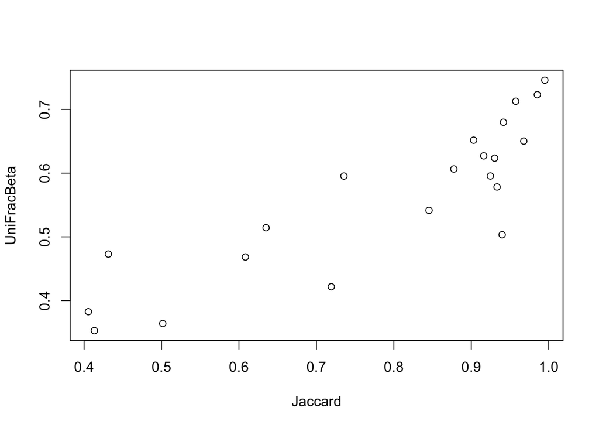

```r
plot(Jaccard,UniFracBeta)
```

And then visualize the pattern of microbiome composition in relation to the metadata, for Unifrac:

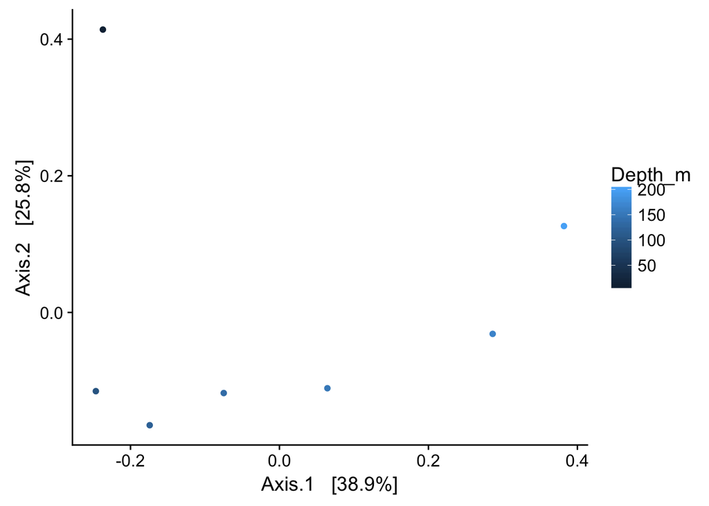

```r
ordi = ordinate(saanish, "PCoA", distance=UniFracBeta)
plot_ordination(saanish, ordi, color="Depth_m")
```

or Bray Curtis:

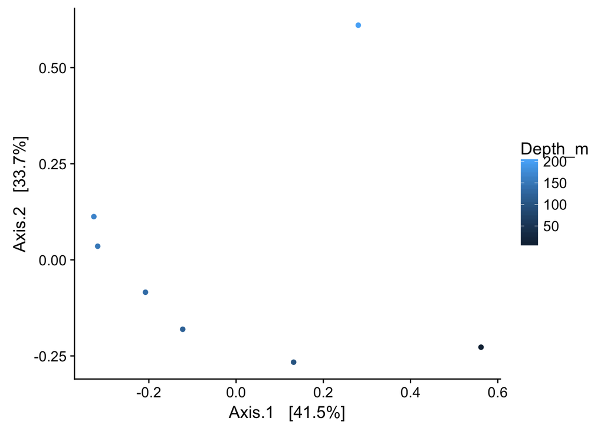

```r
ordi = ordinate(saanish, "PCoA", distance=BC)
plot_ordination(saanish, ordi, color="Depth_m")
```

Importantly, we should also test the statistical relationship between microbiome beta-diversity and the metadata, using for example a PERMANOVA test:

```r
adonis(BC~Depth_m,data=data.frame(sample_data(saanish)))
```

```
##
## Call:
## adonis(formula = BC ~ Depth_m, data = data.frame(sample_data(saanish)))
##
## Permutation: free
## Number of permutations: 999
##
## Terms added sequentially (first to last)
##
##           Df SumsOfSqs MeanSqs F.Model      R2 Pr(>F)
## Depth_m    1    0.5706 0.57060  2.6956 0.35028  0.012 *
## Residuals  5    1.0584 0.21168         0.64972
## Total      6    1.6290                 1.00000
## ---
## Signif. codes:  0 '***' 0.001 '**' 0.01 '*' 0.05 '.' 0.1 ' ' 1
```

```r
adonis(Jaccard~Depth_m,data=data.frame(sample_data(saanish)))
```

```
##
## Call:
## adonis(formula = Jaccard ~ Depth_m, data = data.frame(sample_data(saanish)))
##
## Permutation: free
## Number of permutations: 999
##
## Terms added sequentially (first to last)
##
##           Df SumsOfSqs MeanSqs F.Model      R2 Pr(>F)
## Depth_m    1   0.55829 0.55829   1.952 0.28078  0.029 *
## Residuals  5   1.43006 0.28601         0.71922
## Total      6   1.98835                 1.00000
## ---
## Signif. codes:  0 '***' 0.001 '**' 0.01 '*' 0.05 '.' 0.1 ' ' 1
```

```r
adonis(UniFracBeta~Depth_m,data=data.frame(sample_data(saanish)))
```

```
##
## Call:
## adonis(formula = UniFracBeta ~ Depth_m, data = data.frame(sample_data(saanish)))
##
## Permutation: free
## Number of permutations: 999
##
## Terms added sequentially (first to last)
##
##           Df SumsOfSqs MeanSqs F.Model      R2 Pr(>F)
## Depth_m    1   0.33666 0.33666  2.5783 0.34022  0.003 **
## Residuals  5   0.65287 0.13057         0.65978
## Total      6   0.98953                 1.00000
## ---
## Signif. codes:  0 '***' 0.001 '**' 0.01 '*' 0.05 '.' 0.1 ' ' 1
```

```r
adonis(UniFracBeta~Depth_m+NO3_uM,data=data.frame(sample_data(saanish)))
```

```
##
## Call:
## adonis(formula = UniFracBeta ~ Depth_m + NO3_uM, data = data.frame(sample_data(saanish)))
##
## Permutation: free
## Number of permutations: 999
##
## Terms added sequentially (first to last)
##
##           Df SumsOfSqs MeanSqs F.Model      R2 Pr(>F)
## Depth_m    1   0.33666 0.33666  3.5368 0.34022  0.001 ***
## NO3_uM     1   0.27212 0.27212  2.8587 0.27500  0.005 **
## Residuals  4   0.38076 0.09519         0.38478
## Total      6   0.98953                 1.00000
## ---
## Signif. codes:  0 '***' 0.001 '**' 0.01 '*' 0.05 '.' 0.1 ' ' 1
```

Compare the correlation between environement and taxonomic or phylogenetic compositions

```r
adonis(Jaccard~NO3_uM,data=data.frame(sample_data(saanish)))
```

```
##
## Call:
## adonis(formula = Jaccard ~ NO3_uM, data = data.frame(sample_data(saanish)))
##
## Permutation: free
## Number of permutations: 999
##
## Terms added sequentially (first to last)
##
##           Df SumsOfSqs MeanSqs F.Model      R2 Pr(>F)
## NO3_uM     1   0.52197 0.52197  1.7798 0.26252  0.063 .
## Residuals  5   1.46638 0.29328         0.73748
## Total      6   1.98835                 1.00000
## ---
## Signif. codes:  0 '***' 0.001 '**' 0.01 '*' 0.05 '.' 0.1 ' ' 1
```

```r
adonis(UniFracBeta~NO3_uM,data=data.frame(sample_data(saanish)))
```

```
##
## Call:
## adonis(formula = UniFracBeta ~ NO3_uM, data = data.frame(sample_data(saanish)))
##
## Permutation: free
## Number of permutations: 999
##
## Terms added sequentially (first to last)
##
##           Df SumsOfSqs MeanSqs F.Model      R2 Pr(>F)
## NO3_uM     1   0.29841 0.29841  2.1589 0.30157   0.03 *
## Residuals  5   0.69112 0.13822         0.69843
## Total      6   0.98953                 1.00000
## ---
## Signif. codes:  0 '***' 0.001 '**' 0.01 '*' 0.05 '.' 0.1 ' ' 1
```

### 4.3. Screening the phylogenetic scale

#### 4.3.1 Computing Beta-diversity

We now go a step ahead and screen the phylogentic scale to study the compositipon of the microbiomes. First, we check what are the values of this scale, i.e. the scale of divergence times, in substitution/site.

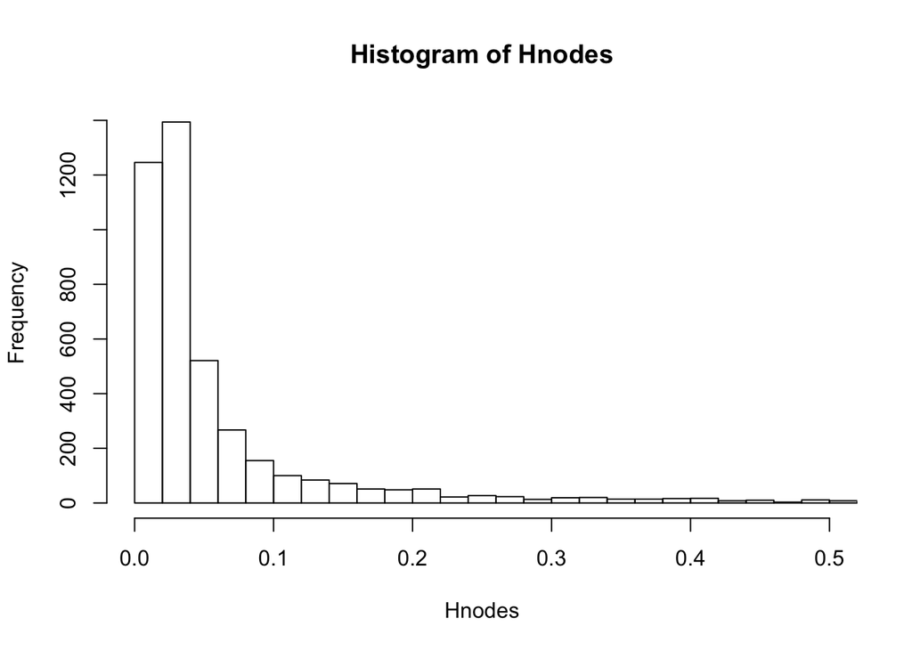

```r
Hnodes=getHnodes(Tree)
hist(Hnodes,n=150,xlim=c(0,.5))
```

We can then define the set of discrete threshold used to build different set of microbial OTUs

```r
slices=c(seq(from=0,to=0.3,by=0.025))
```

The idea the is to compute beta-doversity matrices for all these slices:

We first extract a OTU table matrix from the phyloseq object

```r
mat=t(as(otu_table(saanish), "matrix"))
```

and then run the analysis (for Jaccard and Bray Curtis) and explore the structure of the output (an “array”)

```r
MultipleBetaJac=BDTT(similarity_slices=slices,tree=Tree,sampleOTUs=mat,onlyBeta=T,metric="jac")
```

```
## [1] "0 similarity provides 4315 total new OTUs"
## [1] "0.025 similarity provides 2591 total new OTUs"
## [1] "0.05 similarity provides 1365 total new OTUs"
## [1] "0.075 similarity provides 932 total new OTUs"
## [1] "0.1 similarity provides 733 total new OTUs"
## [1] "0.125 similarity provides 606 total new OTUs"
## [1] "0.15 similarity provides 515 total new OTUs"
## [1] "0.175 similarity provides 435 total new OTUs"
## [1] "0.2 similarity provides 378 total new OTUs"
## [1] "0.225 similarity provides 322 total new OTUs"
## [1] "0.25 similarity provides 291 total new OTUs"
## [1] "0.275 similarity provides 260 total new OTUs"
## [1] "0.3 similarity provides 242 total new OTUs"
```

```r
class(MultipleBetaJac)
```

```
## [1] "array"
```

```r
dim(MultipleBetaJac)
```

```
## [1] 13  7  7
```

```r
MultipleBetaJac
```

```
## , , Saanich_010
##
##       Saanich_010 Saanich_100 Saanich_120 Saanich_135 Saanich_150
## 0               0   0.8326693   0.8488176   0.8217984   0.8715493
## 0.025           0   0.7569866   0.7863196   0.7640614   0.8296578
## 0.05            0   0.6723356   0.6943231   0.6735941   0.7493639
## 0.075           0   0.5958904   0.6465927   0.6256591   0.7120141
## 0.1             0   0.5942982   0.6378270   0.6230248   0.6931567
## 0.125           0   0.5669291   0.6187050   0.6026667   0.6769231
## 0.15            0   0.5454545   0.5882353   0.5920245   0.6500000
## 0.175           0   0.5145985   0.5608108   0.5588235   0.6099291
## 0.2             0   0.5000000   0.5366795   0.5333333   0.5896414
## 0.225           0   0.4696970   0.5227273   0.5242718   0.5761905
## 0.25            0   0.4545455   0.5051020   0.5108696   0.5585106
## 0.275           0   0.4562500   0.4915254   0.4970060   0.5411765
## 0.3             0   0.4635762   0.5060241   0.5031847   0.5500000
##       Saanich_165 Saanich_200
## 0       0.9187872   0.9387755
## 0.025   0.8938182   0.9072238
## 0.05    0.8309002   0.8377724
## 0.075   0.7890223   0.8102564
## 0.1     0.7667387   0.7896996
## 0.125   0.7625000   0.7920792
## 0.15    0.7457143   0.7692308
## 0.175   0.7210884   0.7398649
## 0.2     0.6949807   0.7137405
## 0.225   0.6888889   0.7111111
## 0.25    0.6764706   0.6990291
## 0.275   0.6737968   0.6844920
## 0.3     0.6549708   0.6705202
##
## , , Saanich_100
##
##       Saanich_010 Saanich_100 Saanich_120 Saanich_135 Saanich_150
## 0       0.8326693           0   0.6831276   0.7078431   0.7964043
## 0.025   0.7569866           0   0.4586721   0.5720524   0.7151989
## 0.05    0.6723356           0   0.3765133   0.4586466   0.6210269
## 0.075   0.5958904           0   0.3316062   0.4035714   0.5648464
## 0.1     0.5942982           0   0.3173913   0.3672055   0.5277778
## 0.125   0.5669291           0   0.2955145   0.3314607   0.4974359
```

[output cut: 161 more lines]

```
## 0.3     0.6705202   0.6424870   0.6030151   0.5752688   0.5197740
##       Saanich_165 Saanich_200
## 0       0.8124542           0
## 0.025   0.7360157           0
## 0.05    0.6145511           0
## 0.075   0.5571726           0
## 0.1     0.5225000           0
## 0.125   0.5131965           0
## 0.15    0.4966216           0
## 0.175   0.4942529           0
## 0.2     0.4728033           0
## 0.225   0.4832536           0
## 0.25    0.4795918           0
## 0.275   0.4469274           0
## 0.3     0.4431138           0
```

```r
saveRDS(MultipleBetaJac,"My_outputs/Multiple_Resolution_Beta_Jaccard.RDS")
```

Because it is slow to run (sorry for my code), we will not run bray curtis but directly load it from the BackUp

```r
MultipleBetaBC=readRDS("My_outputs_BackUp/Multiple_Resolution_Beta_BrayCurtis.RDS")
```

#### 4.3.2. Statistical link to metadata

As for the simple beta-diversity tests, we then link the microbiome composition to our metadata. In our case, we need to construct models for each threshold independently:

We first prepare the result table:

```r
predictors=names(sample_data(saanish))
StatsRes=expand.grid(similarity_slices=as.character(slices),predictors=predictors,metric=c("Jac","BC"))
StatsRes[["F.Model"]]=StatsRes[["R2"]]=StatsRes[["Pr(>F)"]]=NA
head(StatsRes)
```

```
##   similarity_slices predictors metric Pr(>F) R2 F.Model
## 1                 0    Depth_m    Jac     NA NA      NA
## 2             0.025    Depth_m    Jac     NA NA      NA
## 3              0.05    Depth_m    Jac     NA NA      NA
## 4             0.075    Depth_m    Jac     NA NA      NA
## 5               0.1    Depth_m    Jac     NA NA      NA
## 6             0.125    Depth_m    Jac     NA NA      NA
```

and then “fill” it without the models that we construct in loop:

```r
for (i in as.character(slices))
{
  for (j in predictors)
  {
   res=unlist(adonis(formula = MultipleBetaJac[i,,]~data.frame(sample_data(saanish))[,j])$aov.tab[1,c(4,5,6)])
   StatsRes[(StatsRes$metric=="Jac")&(StatsRes$predictors==j)&(StatsRes$similarity_slices==i),4:6]=res
   res=unlist(adonis(formula = MultipleBetaBC[i,,]~data.frame(sample_data(saanish))[,j])$aov.tab[1,c(4,5,6)])
   StatsRes[(StatsRes$metric=="BC")&(StatsRes$predictors==j)&(StatsRes$similarity_slices==i),4:6]=res
   }
}
```

We can then plot the profiles of R2 along the phylogenetic time scale:

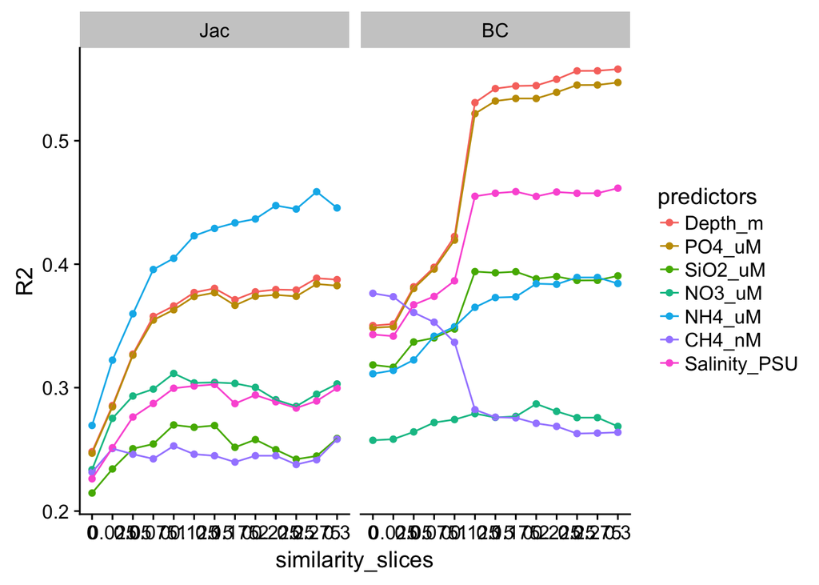

```r
ggplot(aes(y=R2,x=similarity_slices,colour=predictors,group=factor(predictors)),data=StatsRes)+geom_point()+geom_line()+facet_wrap(~metric)
```

```r
ggsave("My_outputs/BDTT_Jaccard_BC.pdf",height = 7,width = 13)
```

## 5. Screening all the nodes of the phylogeny: PhyloFactor

### 5.1. Loading data

We will load data the same data as above. PhyloFactor has some specific requirements for data format that will require further modifications, which are explained below.

The tree:

```r
Tree=read.tree('My_outputs/Saanish_FastTreeRooted')
```

The OTU table:

```r
OTU = read.table("data/Saanich_cruise72_mothur_OTU_table.shared", sep="\t", header=TRUE, row.names=2)
OTU.clean = OTU %>%
  select(-label, -numOtus)

# phylofactor uses OTU tables in matrix format, with features as rows and samples as columns

OTU.matrix <- as.matrix(t(OTU.clean))

# we will need to subset the OTU table to only those tips found in the tree
OTU.matrix <- OTU.matrix[row.names(OTU.matrix) %in% Tree$tip.label,]
```

The taxonomic file:

```r
taxonomy = read.table("data/Saanich_cruise72_mothur_OTU_taxonomy.taxonomy", sep="\t", header=TRUE, row.names=1)
taxonomy.clean = taxonomy %>%
  select(-Size) %>%
  separate(Taxonomy, c("Domain", "Phylum", "Class", "Order", "Family", "Genus", "Species"), sep=";")

taxonomy <- taxonomy %>% select(-Size)
taxonomy$OTU_ID = row.names(taxonomy)
taxonomy <- taxonomy[Tree$tip.label, c('OTU_ID','Taxonomy')]
taxonomy[,2] <- as.character(taxonomy[,2])
```

The metadata:

```r
metadata = read.table("data/Saanich_cruise72_metadata.txt", sep="\t", header=TRUE, row.names=1)
metadata=metadata[,c("Depth_m","PO4_uM","SiO2_uM","NO3_uM","NH4_uM","CH4_nM" ,"Salinity_PSU")]

# similarly, we need to subset metadata to just those samples in our data

metadata <- metadata[colnames(OTU.matrix),]
```

### 5.2. Detecting a simulated variable on the bacterial phylogeny

Fundamentally, PhyloFactorization is a method for seeing how characteristics change across a phylogeny, and identifying the edges of the phylogeny where they change most significantly.

We can demonstrate this by simulating some random data on top of our previously calculated microbial phylogeny, and adjusting the values for a few of the groups. You can imagine this simulated data as a characteristic of the microbes – say, genome size, or cell diameter.

Here, we’re creating a new variable called `CellDiam`, and for each tip on our tree `Tree`, drawing a value from the log normal distribution using the function `rlnorm`. Then, we’ll re-draw values for different subsets of the tree using values that are increased or decreased by 4-fold.

```r
set.seed(1)
CellDiam <- rlnorm(length(Tree$tip.label))

# let's make Arcobacter and Actinobacteria different from the rest

# Grab a Boolean vector corresponding to the Arcobacter and Actinobacteria tip labels of the Tree object
arcobacter <- Tree$tip.label %in% row.names(taxonomy.clean[taxonomy.clean$Genus == 'Arcobacter',])
actinobacteria <- (Tree$tip.label %in% row.names(taxonomy.clean[taxonomy.clean$Phylum == 'Actinobacteria',]))

# Change those tips to have new values for CellDiam drawn from a different distribution
CellDiam[arcobacter] <- rlnorm(sum(arcobacter))*4
CellDiam[actinobacteria] <- rlnorm(sum(actinobacteria))/4

# Take the log of CellDiam variable for analysis
logCellDiam <- log(CellDiam)
```

Now we can PhyloFactor the tree to discover the branches that lead to the tips with the changed values. The function `twoSampleFactor` uses two-sample tests to identify edges separating two parts of the tree that differ with respect to a data vector – in this case, the simulated `CellDiam` values.

```r
pf_twoSample <- twoSampleFactor(logCellDiam, Tree, nfactors=5)
```

```
##
 1 factor completed in 0.0444 minutes.    Estimated time of completion: 2018-06-18 17:13:59

 2 factors completed in 0.111 minutes.     Estimated time of completion: 2018-06-18 17:14:02

 3 factors completed in 0.168 minutes.     Estimated time of completion: 2018-06-18 17:14:02

 4 factors completed in 0.225 minutes.     Estimated time of completion: 2018-06-18 17:14:02

 5 factors completed in 0.279 minutes.     Estimated time of completion: 2018-06-18 17:14:02
```

We can look at a summary of the results by calling the object:

```r
pf_twoSample
```

```
##        phylofactor object from function twoSampleFactor
##        ------------------------------------------------
## Method                    : contrast
## Number of species         : 4315
## Number of factors         : 5
## Largest non-remainder bin : 762
## Number of singletons      : 0
## Paraphyletic Remainder    : 3431 species
##
## -------------------------------------------------------------
## Factor Table:
##                                 Group1                         Group2
## Factor 1 762 member Monophyletic clade 3553 member Paraphyletic clade
## Factor 2 106 member Monophyletic clade 3447 member Paraphyletic clade
## Factor 3  14 member Monophyletic clade 3433 member Paraphyletic clade
## Factor 4                           tip 3432 member Paraphyletic clade
## Factor 5                           tip 3431 member Paraphyletic clade
```

Note that it returned 5 factors, but we only changed two clades on the tree! What happened?

```r
print(sum(actinobacteria))
```

```
## [1] 762
```

```r
print(sum(arcobacter))
```

```
## [1] 102
```

And although statistical significance is still not well-understood for PhyloFactorization, you can see from the vector of p-values associated with these factors that there is a steep drop-off after the first two factors:

```r
pf_twoSample$pvals
```

```
## [1] 3.327912e-234  5.754194e-38  3.650813e-04  3.910677e-04  6.138511e-04
```

We can also visualize these phylogenetic factors on the phylogeny itself using the `pf.tree` function in PhyloFactor, which creates a `ggtree` plot highlighting each returned factor:

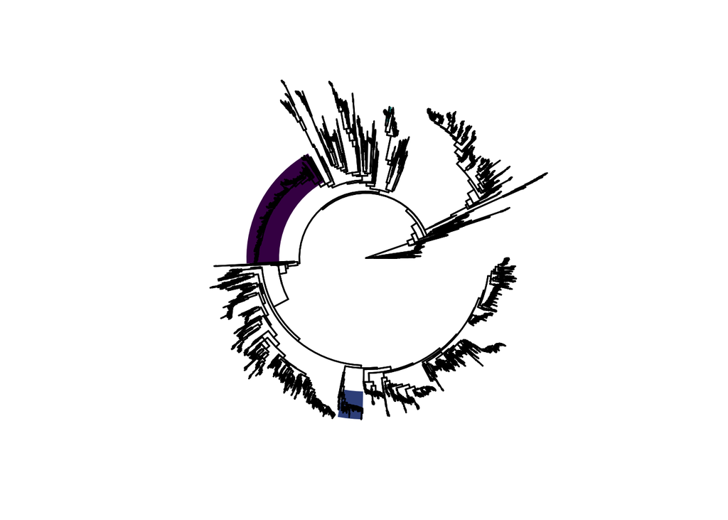

```r
cellDiam.tree <- pf.tree(pf_twoSample)

# Note that the object created by pf.tree has two parts: $legend, which contains
# the colors used for each factor, and $ggplot, which has the ggplot object

cellDiam.tree$ggplot
```

Factor colors are written out as a separate legend element in the returned object:

```r
cellDiam.tree$legend
```

```
##   factor group    colors
## 1      1     1 #440154FF
## 2      2     1 #3B528BFF
## 3      3     1 #21908CFF
## 4      4     1 #5DC863FF
## 5      5     1 #FDE725FF
```